# Klimaat streepjescode

Auteur

Erwin Bramer

Publicatiedatum

11 januari 2025

# Introductie

Deze blog gaat over de *Warming Stripes* in het Nederlands ook wel de klimaat streepjescode genoemd. Ik vind de klimaat streepjescode heel interessant omdat hierin twee zaken bij elkaar komen waar ik veel belangstelling voor heb: de opwarming van de aarde en datavisualisatie. Professor Ed Hawkins van de Universiteit van Reading is de bedenker van deze minimalistische en toch geniale datavisualisatie. Zonder cijfers, zonder grafieklijnen heeft hij toch iets gecreeërd waaruit in één oogopslag duidelijk wordt wat er aan de hand is.

In deze blog ga ik met behulp van `R` deze wereldberoemde klimaat streepjescode nabouwen voor de wereld temperatuur en voor mijn regio Twente.

# Het kleurenschema

Voor een gelijkende figuur hebben we uiteraard het kleurenschema dat professor Hawkins heeft gebruikt nodig. Het kleurenschema heb ik via [Wikipedia](https://en.wikipedia.org/wiki/Warming_stripes) gevonden. Het schema bevat 8 blauw en 8 rood tinten plus wit. In totaal dus 17 kleuren.

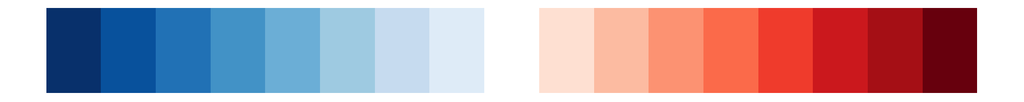

Figuur 1: Kleurenschema voor de klimaat streepjescode van donkerblauw (koudst) tot donkerrood (warmst)

# De data

## De wereld

De data voor de wereldtemperatuur is afkomstig van de Engelse [Met Office](https://www.metoffice.gov.uk/). Meer specifiek van de Met Office Hadley Centre[^1]. De dataset is gepresenteerd als de afwijking (**anomaly**) van de gemiddelde temperatuur in de jaren 1961-1990.

Laten we eerst eens kijken hoe de data van het UK Met Office er uitziet.

```r
summary(world)
```

```
      time      anomaly_deg_c      lower_confidence_limit_2_5_percent
 Min.   :1850   Min.   :-0.59751   Min.   :-0.72496
 1st Qu.:1894   1st Qu.:-0.34129   1st Qu.:-0.48143
 Median :1937   Median :-0.17434   Median :-0.25913
 Mean   :1937   Mean   :-0.06502   Mean   :-0.16022
 3rd Qu.:1980   3rd Qu.: 0.09327   3rd Qu.: 0.03786
 Max.   :2024   Max.   : 1.17769   Max.   : 1.13847
 upper_confidence_limit_97_5_percent
 Min.   :-0.47007
 1st Qu.:-0.20970
 Median :-0.07467
 Mean   : 0.03018
 3rd Qu.: 0.20061
 Max.   : 1.21692
```

OK, dat ziet er eenvoudig uit. Eén variabele voor het jaar `Time` en een variabele voor de afwijking van de gemiddelde temperatuur `Anomaly (deg C)` plus twee variabelen voor de onzekerheid in de data. De data staat dus al in jaar en afwijking formaat. Daarmee kunnen we eenvoudig een streepjescode grafiek maken. De data loopt van 1850 tot en met 2024. De spreiding in de afwijking is 1,78 graden Celsius. Laten we eens controleren of de afwijking inderdaad is ten opzichte van het gemiddelde over de jaren 1961 t/m 1990.

```r
world |>
  filter(time >= 1961, time <= 1990) |>
  summarise(
    afwijking = mean(anomaly_deg_c)
  )
```

```
# A tibble: 1 × 1
  afwijking
      <dbl>
1   0.00768
```

Op één decimaal achter de komma is het inderdaad gelijk aan 0,0.

## Vliegveld Twenthe

De data voor de temperatuur in Twente is afkomstig van het [KNMI](https://www.knmi.nl/nederland-nu/klimatologie/daggegevens). Het KNMI publiceert daggevens voor veel verschillende weerstations in Nederland. Ook vliegveld Twenthe heeft een weerstation. De KNMI-code voor vliegveld Twenthe is 290. Het gedownloade zip-bestand voor Twente heb ik uitgepakt en de weergegevens staan in etmgeg_290.txt. Uit dit bestand nemen we de datum `yyyymmdd` en de gemiddelde dagtemperatuur `tg`.

Samengevat zit deze dataframe er dan zo uit:

```r
summary(weer)
```

```
    yyyymmdd              tg
 Min.   :19510101   Min.   :-15.500
 1st Qu.:19690702   1st Qu.:  4.800
 Median :19880101   Median :  9.800
 Mean   :19875672   Mean   :  9.576
 3rd Qu.:20060702   3rd Qu.: 14.600
 Max.   :20241231   Max.   : 30.500
                    NA's   :9
```

Deze gegevens zijn per dag verzameld. We zullen deze dus nog moeten omzetten naar jaargemiddelden. We zien ook dat er 9 NA’s zijn. We zullen deze negeren en de gemiddelde jaartemperatuur meten over de overige dagen die wel gemeten zijn. Er is nog een waarschuwing op zijn plaats. De gegevens van het weerstation zijn niet gehomogeniseerd. Dit betekent dat de data beïnvloedt kunnen zijn door dat het meetstation op een of meerdere momenten is verplaatst.

De data voor het plotten berekenen we in drie stappen. Eerst bepalen we de gemiddelde temperatuur per jaar. Stap 2 is het berekenen van de gemiddelde temperatuur in de referentieperiode 1961-19900. Tenslotte berekenen we de afwijking van de jaartemperatuur ten opzichte van de referentiewaarde.

```r
# Berekenen van de gemiddelde jaartemperatuur
weer <- weer |>
  mutate(
    jaar = as.integer( year(ymd(yyyymmdd)) )
  ) |>
  group_by(jaar) |>
  summarise(
    t_gem = mean(tg, na.rm = TRUE)
  )

# De gemiddelde temperatuur in de referentieperiode 1961 - 1990.
ref_gem <- weer |>
  filter(
    jaar >= 1961, jaar <= 1990
  ) |>
  summarise(
    t_gem = mean(t_gem)
  ) |>
  pull()

# Tenslotte berekenen van de afwijking van de jaartemperatuur van het gemiddelde
# in de referentieperiode.
weer <- weer |>
  mutate(
    afwijking = t_gem - ref_gem
  )
```

Na deze bewerkingsslagen zijn we klaar om ook voor Twente de klimaat streepjescode te maken.

# Klimaat streepjescodes

## Wereld

Voor het maken van de klimaat streepjescode gebruiken we het commando `scale_fill_stepsn()`. Dit commando gebruikt een discrete schaal om de streepjes te kleuren. Eén van de argumenten die we mee kunnen geven is het aantal stappen dat we willen gebruiken. In ons geval `n.breaks = 17`.

[figure not shown]

Figuur 2: De klimaat streepjescode voor de wereld van 1850 - 2024. Bron: UK Met Office

```r
world |>
  rename(
    jaar = time,
    afwijking = anomaly_deg_c
  ) |>
  ggplot(aes(x = jaar, y = 1, fill = afwijking)) +
  geom_col(width = 1, show.legend = FALSE) +
  scale_fill_stepsn(n.breaks = 17, colours = wscolors) +
  theme_void()
```

## Twente

[figure not shown]

Figuur 3: De klimaat streepjescode voor Twente van 1951 - 2024. Bron: KNMI daggegevens

```r
weer |>
  ggplot(aes(x = jaar, y = 1, fill = afwijking)) +
  geom_col(width = 1, show.legend = FALSE) +
  scale_fill_stepsn(n.breaks = 17, colours = wscolors) +
  theme_void()
```

In Figuur 3 valt op dat de variatie in de temperatuur in de jaren 1951 t/m 2024 veel groter is dan voor de wereld. Dat is natuurlijk ook niet zo gek. Voor Twente kijken we naar een weerstation, terwijl de wereld temperatuur gebaseerd is op heel veel weerstations waardoor de variantie afneemt. De figuur laat veel minder blauwe kleuren zien in vergelijking met de streepjescode voor de wereld. Net als de wereld zien we in Figuur 3 dat de laatste jaren heel warm zijn geweest en dat 2024 het warmste jaar ooit gemeten is voor Twente. We kunnen ook even kijken naar de zes warmste jaren.

```r
weer |>
  arrange(-t_gem) |>
  head()
```

```
# A tibble: 6 × 3
   jaar t_gem afwijking
  <int> <dbl>     <dbl>
1  2024  11.5      2.52
2  2023  11.4      2.45
3  2022  11.4      2.43
4  2014  11.3      2.32
5  2020  11.3      2.30
6  2018  11.2      2.21
```

[home](https://erwinbramer.github.io/)

## Voetnoten

[^1]: Morice, C. P., Kennedy, J. J., Rayner, N. A., Winn, J. P., Hogan, E., Killick, R. E., et al. (2021). An updated assessment of near-surface temperature change from 1850: the HadCRUT5 data set. Journal of Geophysical Research: Atmospheres, 126, e2019JD032361. https://doi.org/10.1029/2019JD032361